# R Final Project

## Overview

The Student Social Media & Relationships dataset contains anonymized records of students’ social‐media behaviors and related life outcomes. It spans multiple countries and academic levels, focusing on key dimensions such as usage intensity, platform preferences, and relationship dynamics. Each row represents one student’s survey response, offering a cross‐sectional snapshot suitable for statistical analysis and machine‐learning applications.

## Scope & Coverage

Population: Students aged 18–24 enrolled in high school, undergraduate, or graduate programs.

Geography: Multi‐country coverage (e.g., Bangladesh, India, USA, UK, Canada, Australia, Germany, Brazil, Japan, South Korea).

## Column Descriptions

*Student_ID* A unique integer identifier assigned to each survey respondent to enable de-duplication and track individual records without revealing personal information.

*Age* The student’s age in completed years at the time of the survey, used to segment analysis by age group and control for developmental differences.

*Gender* The student’s self-reported gender, recorded as “Male” or “Female” to allow for demographic breakdowns in usage and outcome measures.

*Academic_Level* The highest level of education the respondent is currently enrolled in, with categories: “High School,” “Undergraduate,” or “Graduate,” facilitating stratified analyses by academic stage.

*Country* The country of residence where the student completed the survey, enabling cross-country comparisons of social media behaviors and impacts.

*Avg_Daily_Usage_Hours* The average number of hours per day the student spends on social media platforms, calculated from self-reported weekday and weekend usage estimates.

*Most_Used_Platform* The social media platform on which the student spends the most time (e.g., Instagram, Facebook, TikTok), used to examine platform-specific effects.

*Affects_Academic_Performance* A binary indicator (“Yes”/“No”) reflecting whether the student perceives their social media use as having a negative impact on their academic performance.

*Sleep_Hours_Per_Night* The respondent’s average nightly sleep duration in hours, provided to investigate correlations between screen time and sleep quality/quantity.

*Mental_Health_Score* A self-rated integer from 1 (poor) to 10 (excellent) indicating overall mental well-being, allowing assessment of potential associations with social media habits.

*Relationship_Status* The student’s current romantic relationship status, categorized as “Single,” “In Relationship,” or “Complicated,” to explore social media’s impact on interpersonal dynamics.

*Conflicts_Over_Social_Media* The number of arguments or disagreements the student reports having had with family, friends, or partners due to their social media use, serving as a proxy for social friction.

*Addicted_Score* A composite score from 1 (low addiction) to 10 (high addiction) based on a standardized survey scale (e.g., Bergen Social Media Addiction Scale), quantifying the degree of problematic usage.

```r
library(tidyverse)
students <- read.csv("C:/Users/asroka/OneDrive - Adobe/Desktop/Anna/MTech/R/Final Project/Students Social Media Addiction.csv")
```

```r
head(students)
```

```
##   Student_ID Age Gender Academic_Level    Country Avg_Daily_Usage_Hours
## 1          1  19 Female  Undergraduate Bangladesh                   5.2
## 2          2  22   Male       Graduate      India                   2.1
## 3          3  20 Female  Undergraduate        USA                   6.0
## 4          4  18   Male    High School         UK                   3.0
## 5          5  21   Male       Graduate     Canada                   4.5
## 6          6  19 Female  Undergraduate  Australia                   7.2
##   Most_Used_Platform Affects_Academic_Performance Sleep_Hours_Per_Night
## 1          Instagram                          Yes                   6.5
## 2            Twitter                           No                   7.5
## 3             TikTok                          Yes                   5.0
## 4            YouTube                           No                   7.0
## 5           Facebook                          Yes                   6.0
## 6          Instagram                          Yes                   4.5
##   Mental_Health_Score Relationship_Status Conflicts_Over_Social_Media
## 1                   6     In Relationship                           3
## 2                   8              Single                           0
## 3                   5         Complicated                           4
## 4                   7              Single                           1
## 5                   6     In Relationship                           2
## 6                   4         Complicated                           5
##   Addicted_Score perc_daily_usage perc_sleep
## 1              8              22%        27%
## 2              3               9%        31%
## 3              9              25%        21%
## 4              4              13%        29%
## 5              7              19%        25%
## 6              9              30%        19%
```

## *ANALYSIS*

### Data Cleaning

Checking for missing values:

```r
colSums(is.na(students))
```

```
##                   Student_ID                          Age
##                            0                            0
##                       Gender               Academic_Level
##                            0                            0
##                      Country        Avg_Daily_Usage_Hours
##                            0                            0
##           Most_Used_Platform Affects_Academic_Performance
##                            0                            0
##        Sleep_Hours_Per_Night          Mental_Health_Score
##                            0                            0
##          Relationship_Status  Conflicts_Over_Social_Media
##                            0                            0
##               Addicted_Score             perc_daily_usage
##                            0                            0
##                   perc_sleep
##                            0
```

We have no missing values in our dataset. Next step is checking the data types.

```r
str(students)
```

```
## 'data.frame':    705 obs. of  15 variables:
##  $ Student_ID                  : int  1 2 3 4 5 6 7 8 9 10 ...
##  $ Age                         : int  19 22 20 18 21 19 23 20 18 21 ...
##  $ Gender                      : chr  "Female" "Male" "Female" "Male" ...
##  $ Academic_Level              : chr  "Undergraduate" "Graduate" "Undergraduate" "High School" ...
##  $ Country                     : chr  "Bangladesh" "India" "USA" "UK" ...
##  $ Avg_Daily_Usage_Hours       : num  5.2 2.1 6 3 4.5 7.2 1.5 5.8 4 3.3 ...
##  $ Most_Used_Platform          : chr  "Instagram" "Twitter" "TikTok" "YouTube" ...
##  $ Affects_Academic_Performance: chr  "Yes" "No" "Yes" "No" ...
##  $ Sleep_Hours_Per_Night       : num  6.5 7.5 5 7 6 4.5 8 6 6.5 7 ...
##  $ Mental_Health_Score         : int  6 8 5 7 6 4 9 6 7 7 ...
##  $ Relationship_Status         : chr  "In Relationship" "Single" "Complicated" "Single" ...
##  $ Conflicts_Over_Social_Media : int  3 0 4 1 2 5 0 2 1 1 ...
##  $ Addicted_Score              : int  8 3 9 4 7 9 2 8 5 4 ...
##  $ perc_daily_usage            : chr  "22%" "9%" "25%" "13%" ...
##  $ perc_sleep                  : chr  "27%" "31%" "21%" "29%" ...
```

Let’s see if we have any duplications.

```r
sum(duplicated(students))
```

```
## [1] 0
```

Our dataset does not have duplicated values.

### Data manipulation

Let’s apply some filters to check how many males and females from the USA spend more than 6 hours a day on social media. 6 hours represents 25% of the whole day.

```r
filter(students, Gender == "Male", Country == "USA", Avg_Daily_Usage_Hours >= 6)
```

```
##  [1] Student_ID                   Age
##  [3] Gender                       Academic_Level
##  [5] Country                      Avg_Daily_Usage_Hours
##  [7] Most_Used_Platform           Affects_Academic_Performance
##  [9] Sleep_Hours_Per_Night        Mental_Health_Score
## [11] Relationship_Status          Conflicts_Over_Social_Media
## [13] Addicted_Score               perc_daily_usage
## [15] perc_sleep
## <0 rows> (or 0-length row.names)
```

Now, we will apply the same criteria for females.

```r
filter(students, Gender == "Female", Country == "USA", Avg_Daily_Usage_Hours >= 6)
```

```
##    Student_ID Age Gender Academic_Level Country Avg_Daily_Usage_Hours
## 1           3  20 Female  Undergraduate     USA                   6.0
## 2         221  19 Female  Undergraduate     USA                   6.5
## 3         229  19 Female  Undergraduate     USA                   7.0
## 4         237  19 Female  Undergraduate     USA                   6.8
## 5         245  19 Female  Undergraduate     USA                   6.9
## 6         253  19 Female  Undergraduate     USA                   6.7
## 7         261  19 Female  Undergraduate     USA                   6.6
## 8         269  19 Female  Undergraduate     USA                   6.4
## 9         277  19 Female  Undergraduate     USA                   6.6
## 10        285  19 Female  Undergraduate     USA                   6.7
## 11        293  19 Female  Undergraduate     USA                   6.8
## 12        301  19 Female  Undergraduate     USA                   6.9
## 13        309  19 Female  Undergraduate     USA                   7.0
## 14        317  19 Female  Undergraduate     USA                   7.1
```

[output cut: 117 more lines]

We have 32 females from the USA that spend more than 6 hours on their social media, whereas none of males. This is an interesting result and we will dive deeper into analysis later on.

We will now calculate percentage of average daily usage and percentage of sleep at night. To do so, we will use mutate function.

```r
mutate(students, perc_daily_usage = round(Avg_Daily_Usage_Hours /  24*100,0), perc_sleep = round(Sleep_Hours_Per_Night / 24 *100,0)
)
```

```
##     Student_ID Age Gender Academic_Level         Country Avg_Daily_Usage_Hours
## 1            1  19 Female  Undergraduate      Bangladesh                   5.2
## 2            2  22   Male       Graduate           India                   2.1
## 3            3  20 Female  Undergraduate             USA                   6.0
## 4            4  18   Male    High School              UK                   3.0
## 5            5  21   Male       Graduate          Canada                   4.5
## 6            6  19 Female  Undergraduate       Australia                   7.2
## 7            7  23   Male       Graduate         Germany                   1.5
## 8            8  20 Female  Undergraduate          Brazil                   5.8
## 9            9  18   Male    High School           Japan                   4.0
## 10          10  21 Female       Graduate     South Korea                   3.3
## 11          11  19   Male  Undergraduate          France                   4.8
## 12          12  20 Female  Undergraduate           Spain                   5.5
## 13          13  22   Male       Graduate           Italy                   2.8
## 14          14  18 Female    High School          Mexico                   6.5
```

[output cut: 2809 more lines]

Next step is to add categories for addiction level and sleep hours.

```r
addiction_description <- students %>%
mutate(addiction_category = case_when(
  Avg_Daily_Usage_Hours < 2 ~ "Low risk addiction",
  Avg_Daily_Usage_Hours >= 2 & Avg_Daily_Usage_Hours < 4 ~ "Moderate risk addiction",
  Avg_Daily_Usage_Hours >= 4 ~ "High risk addiction",
  TRUE ~ NA_character_
))
```

```r
sleep_description <- students %>%
mutate(sleep_category = case_when(
  Sleep_Hours_Per_Night < 5 ~ "Poor (<5h)",
  Sleep_Hours_Per_Night >= 5 & Sleep_Hours_Per_Night < 7 ~ "Fair (7-9h)",
  Sleep_Hours_Per_Night >= 4 ~ "Good (9h+)",
  TRUE ~ NA_character_
))
```

Let’s provide some summaries and check the findings.

```r
platform_usage <- group_by(students,Most_Used_Platform)
summarise(
  platform_usage,
  Female = round(mean(Avg_Daily_Usage_Hours[Gender == "Female"],na.rm = TRUE), 2),
  Male = round(mean(Avg_Daily_Usage_Hours[Gender == "Male"],na.rm = TRUE), 2)
)
```

```
## # A tibble: 12 × 3
##    Most_Used_Platform Female   Male
##    <chr>               <dbl>  <dbl>
##  1 Facebook             4.79   4.44
##  2 Instagram            4.88   4.86
##  3 KakaoTalk            4.72 NaN
##  4 LINE                 3.25 NaN
##  5 LinkedIn             2.65   2.44
##  6 Snapchat             5.12   5.04
##  7 TikTok               5.61   5.02
##  8 Twitter              4.95   4.78
##  9 VKontakte          NaN      4.25
## 10 WeChat               5.62   4.72
## 11 WhatsApp             6.66   6.43
## 12 YouTube            NaN      4.08
```

### Statistical Analysis

Summary for Students’ age column.

```r
summary(students$Age)
```

```
##    Min. 1st Qu.  Median    Mean 3rd Qu.    Max.
##   18.00   19.00   21.00   20.66   22.00   24.00
```

Summary for Students’ average daily usage hours column.

```r
summary(students$Avg_Daily_Usage_Hours )
```

```
##    Min. 1st Qu.  Median    Mean 3rd Qu.    Max.
##   1.500   4.100   4.800   4.919   5.800   8.500
```

Summary for Students’ sleep hours per night column.

```r
summary(students$Sleep_Hours_Per_Night)
```

```
##    Min. 1st Qu.  Median    Mean 3rd Qu.    Max.
##   3.800   6.000   6.900   6.869   7.700   9.600
```

Summary for Students’ mental health score column.

```r
summary( students$Mental_Health_Score)
```

```
##    Min. 1st Qu.  Median    Mean 3rd Qu.    Max.
##   4.000   5.000   6.000   6.227   7.000   9.000
```

```r
summary(students[, c("Age", "Avg_Daily_Usage_Hours", "Sleep_Hours_Per_Night", "Mental_Health_Score")])
```

```
##       Age        Avg_Daily_Usage_Hours Sleep_Hours_Per_Night
##  Min.   :18.00   Min.   :1.500         Min.   :3.800
##  1st Qu.:19.00   1st Qu.:4.100         1st Qu.:6.000
##  Median :21.00   Median :4.800         Median :6.900
##  Mean   :20.66   Mean   :4.919         Mean   :6.869
##  3rd Qu.:22.00   3rd Qu.:5.800         3rd Qu.:7.700
##  Max.   :24.00   Max.   :8.500         Max.   :9.600
##  Mental_Health_Score
##  Min.   :4.000
##  1st Qu.:5.000
##  Median :6.000
##  Mean   :6.227
##  3rd Qu.:7.000
##  Max.   :9.000
```

Let’s calculate T-test comparing addiction scores between genders, meaning testing whether the mean Addicted_Score differs between Female and Male students.

```r
t.test(Addicted_Score ~ Gender, data = students)
```

```
##
##  Welch Two Sample t-test
##
## data:  Addicted_Score by Gender
## t = 1.3195, df = 685.84, p-value = 0.1875
## alternative hypothesis: true difference in means between group Female and group Male is not equal to 0
## 95 percent confidence interval:
##  -0.0769293  0.3921817
## sample estimates:
## mean in group Female   mean in group Male
##             6.515581             6.357955
```

✅ Conclusion:

*p-value = 0.1875* is greater than 0.05, so we fail to reject the null hypothesis.

This means there is no statistically significant difference in Addicted_Score between females and males in your data.

The confidence interval includes 0, which also supports no significant difference. There’s not enough evidence to say that female and male students differ in their average Addicted_Score in this dataset.

Now, we will calculate correlations between key variables.

```r
corr_a <- lm(Avg_Daily_Usage_Hours ~ Addicted_Score, data = students)
```

```r
summary(corr_a)
```

```
##
## Call:
## lm(formula = Avg_Daily_Usage_Hours ~ Addicted_Score, data = students)
##
## Residuals:
##      Min       1Q   Median       3Q      Max
## -1.84903 -0.51250  0.06924  0.49184  2.01011
##
## Coefficients:
##                Estimate Std. Error t value Pr(>|t|)
## (Intercept)     0.67597    0.10989   6.151 1.29e-09 ***
## Addicted_Score  0.65913    0.01658  39.763  < 2e-16 ***
## ---
## Signif. codes:  0 '***' 0.001 '**' 0.01 '*' 0.05 '.' 0.1 ' ' 1
##
## Residual standard error: 0.6981 on 703 degrees of freedom
## Multiple R-squared:  0.6922, Adjusted R-squared:  0.6918
## F-statistic:  1581 on 1 and 703 DF,  p-value: < 2.2e-16
```

Correlation Analysis:

**Usage Hours vs Addiction Score:**

✅ Interpretation of Coefficients:

*Intercept = 0.676* When Addicted_Score is 0, the predicted average daily usage is 0.676 hours.

*Addicted_Score = 0.659* For every 1-point increase in Addicted_Score, Avg_Daily_Usage_Hours increases by 0.659 hours, on average. This is a positive linear relationship.

*p-values (< 2e-16)* Both the intercept and slope are highly statistically significant, indicating the relationship is not due to random chance.

📊 Metric Interpretation *Multiple R-squared = 0.6922* The model explains 69.2% of the variance in average daily usage. This is very strong for social science data.

*Adjusted R-squared = 0.6918* Adjusted for number of predictors — still high.

*Residual standard error = 0.6981* Average size of prediction errors is about 0.70 hours.

*F-statistic = 1581, p < 2.2e-16* The overall regression model is statistically significant.

🔍 There is a strong, statistically significant positive relationship between Addicted_Score and Avg_Daily_Usage_Hours. Higher addiction scores are strongly associated with more screen time per day.

[output not shown]

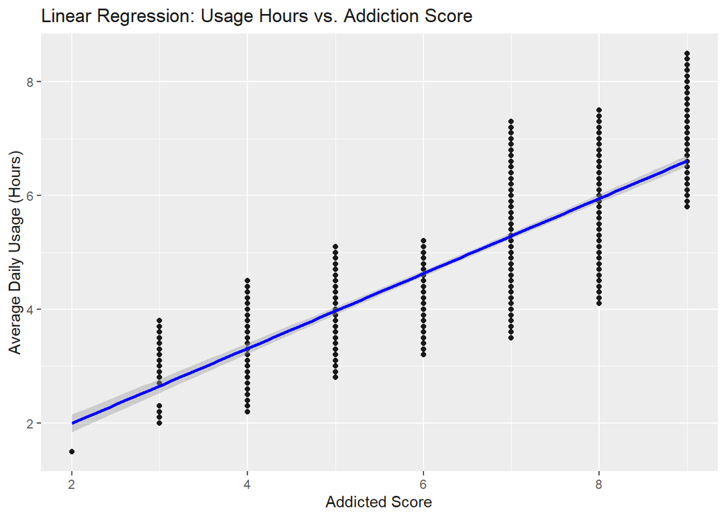

```r
ggplot(students, aes(x = Addicted_Score, y = Avg_Daily_Usage_Hours)) +
  geom_point() +
  geom_smooth(method = "lm", se = TRUE, color = "blue") +
  labs(title = "Linear Regression: Usage Hours vs. Addiction Score",
       x = "Addicted Score",
       y = "Average Daily Usage (Hours)")
```

```r
corr_b <- lm(Avg_Daily_Usage_Hours ~ Sleep_Hours_Per_Night, data = students)

summary(corr_b)
```

```
##
## Call:
## lm(formula = Avg_Daily_Usage_Hours ~ Sleep_Hours_Per_Night, data = students)
##
## Residuals:
##      Min       1Q   Median       3Q      Max
## -2.86140 -0.26171  0.07333  0.52651  1.47333
##
## Coefficients:
##                       Estimate Std. Error t value Pr(>|t|)
## (Intercept)           10.97831    0.17938   61.20   <2e-16 ***
## Sleep_Hours_Per_Night -0.88217    0.02577  -34.23   <2e-16 ***
## ---
## Signif. codes:  0 '***' 0.001 '**' 0.01 '*' 0.05 '.' 0.1 ' ' 1
##
## Residual standard error: 0.7705 on 703 degrees of freedom
## Multiple R-squared:  0.625,  Adjusted R-squared:  0.6245
## F-statistic:  1172 on 1 and 703 DF,  p-value: < 2.2e-16
```

**Usage Hours vs Sleep Hours:**

✅ Interpretation of Coefficients:

*Intercept 10.978* If a student gets 0 hours of sleep, their predicted screen time is 10.98 hours/day. (This is a theoretical value, not practically meaningful.)

*Sleep_Hours_Per_Night -0.882* For each additional hour of sleep, the average screen usage decreases by 0.88 hours/day. This shows a strong negative linear relationship.

*p-values (< 2e-16)* The relationship is highly statistically significant. The probability this happened by chance is nearly 0.

📊 Model Fit Metrics:

*Multiple R-squared = 0.625* About 62.5% of the variation in screen usage is explained by sleep duration. That’s strong for behavioral data.

*Residual standard error = 0.7705* On average, predictions deviate from the actual values by about 0.77 hours/day.

*F-statistic = 1172, p < 2.2e-16* The model is statistically significant overall.

🔍 Students who sleep more tend to spend less time on screens per day. The relationship is strong, negative, and statistically significant.

[output not shown]

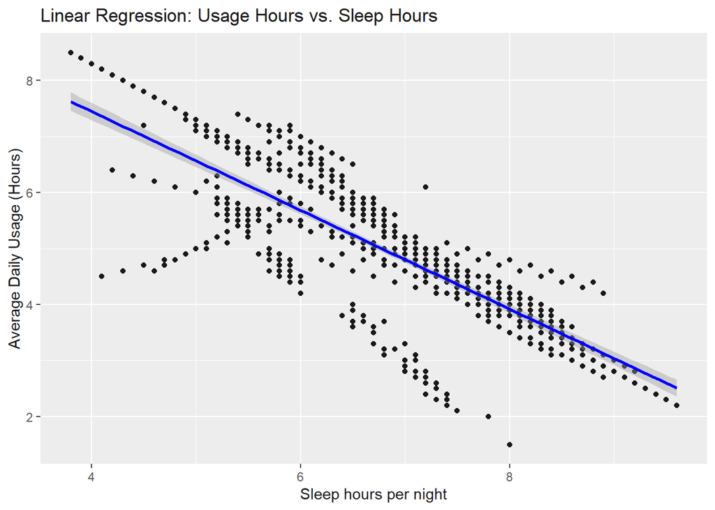

```r
ggplot(students, aes(x = Sleep_Hours_Per_Night, y = Avg_Daily_Usage_Hours)) +
  geom_point() +
  geom_smooth(method = "lm", se = TRUE, color = "blue") +
  labs(title = "Linear Regression: Usage Hours vs. Sleep Hours",
       x = "Sleep hours per night",
       y = "Average Daily Usage (Hours)")
```

```r
corr_c <- lm(Avg_Daily_Usage_Hours ~ Mental_Health_Score, data = students)

summary(corr_c)
```

```
##
## Call:
## lm(formula = Avg_Daily_Usage_Hours ~ Mental_Health_Score, data = students)
##
## Residuals:
##      Min       1Q   Median       3Q      Max
## -2.23707 -0.51410  0.07441  0.48590  2.46293
##
## Coefficients:
##                     Estimate Std. Error t value Pr(>|t|)
## (Intercept)         10.59452    0.16246   65.22   <2e-16 ***
## Mental_Health_Score -0.91149    0.02569  -35.48   <2e-16 ***
## ---
## Signif. codes:  0 '***' 0.001 '**' 0.01 '*' 0.05 '.' 0.1 ' ' 1
##
## Residual standard error: 0.7532 on 703 degrees of freedom
## Multiple R-squared:  0.6417, Adjusted R-squared:  0.6412
## F-statistic:  1259 on 1 and 703 DF,  p-value: < 2.2e-16
```

**Usage Hours vs Mental Health:**

✅ Interpretation of Coefficients: *Intercept 10.59* This means when Mental_Health_Score = 0, the expected average daily usage is 10.59 hours.

*Mental_Health_Score Coefficient = -0.91149* For every 1 unit increase in mental health score, the average daily social media usage decreases by ~0.91 hours, holding other factors constant.

The negative sign suggests an inverse relationship — better mental health (higher score) is associated with less social media use.

*p-value < 2e-16* → extremely small. This coefficient is highly statistically significant, meaning the relationship is almost certainly not due to chance.

📊 Model Fit Metrics:

*R-squared = 0.6417* About 64.2% of the variability in Avg_Daily_Usage_Hours is explained by Mental_Health_Score. This is a strong R² value for social/behavioral data.

*Residual Standard Error = 0.7532* On average, the model’s predictions are off by ~0.75 hours.

🔍 There is a strong, statistically significant negative correlation between mental health scores and average daily social media usage. Specifically, individuals with higher mental health scores tend to use social media significantly less, and the model explains about 64% of the variation in usage.

[output not shown]

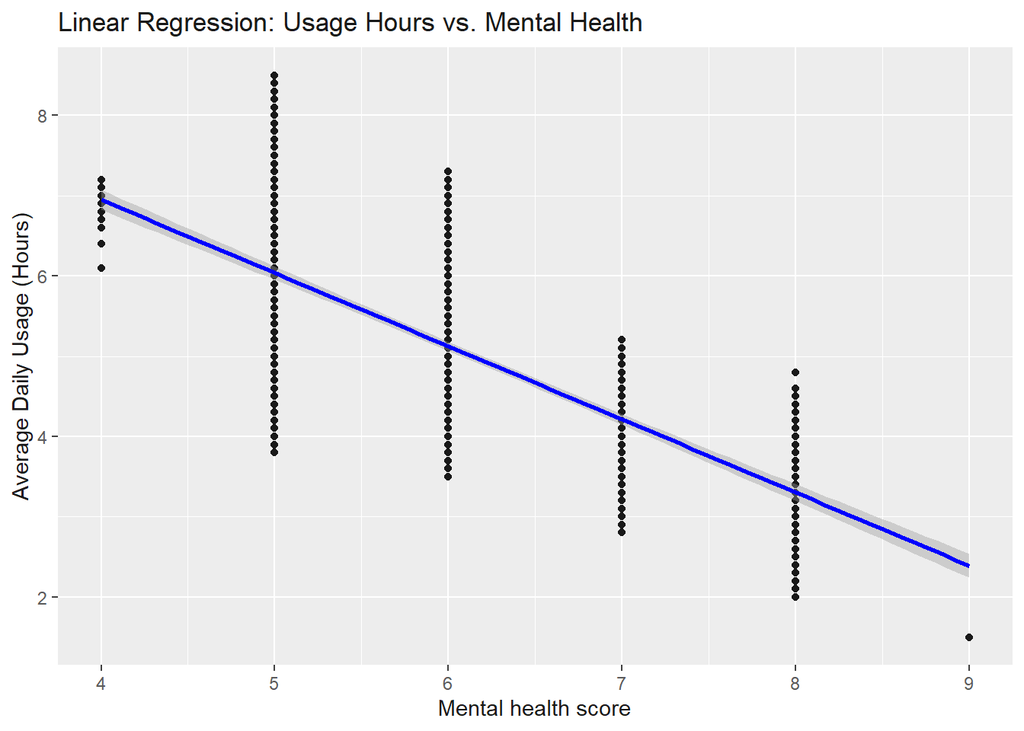

```r
ggplot(students, aes(x = Mental_Health_Score, y = Avg_Daily_Usage_Hours)) +
  geom_point() +
  geom_smooth(method = "lm", se = TRUE, color = "blue") +
  labs(title = "Linear Regression: Usage Hours vs. Mental Health",
       x = "Mental health score",
       y = "Average Daily Usage (Hours)")
```

### Data Visualization

[output not shown]

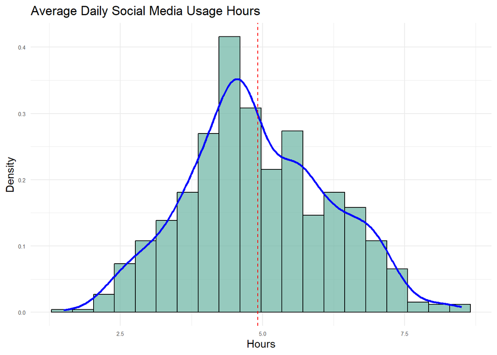

```r
ggplot(data = students, aes(x = Avg_Daily_Usage_Hours)) +
  geom_histogram(aes(y = after_stat(density)), bins = 20, fill = "#69b3a2", color = "black", alpha = 0.7) +
  geom_density(color = "blue", linewidth = 1) +
  geom_vline(aes(xintercept = mean(Avg_Daily_Usage_Hours, na.rm = TRUE)),
             color = "red", linetype = "dashed") +
  labs(
    title = "Average Daily Social Media Usage Hours",
    x = "Hours",
    y = "Density"
  ) +
  theme_minimal()
```

Average daily hours on the social media platforms is 4.92.

```r
round(mean(students$Avg_Daily_Usage_Hours),2)
```

```
## [1] 4.92
```

[output not shown]

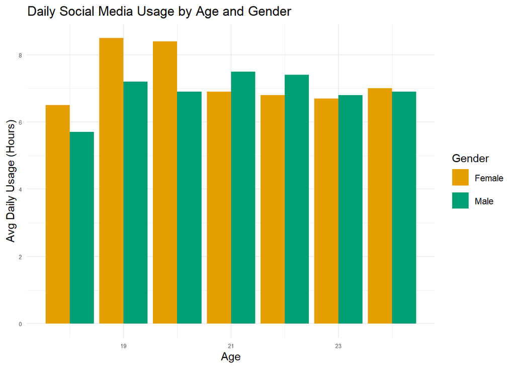

```r
ggplot(data = students, aes(x = Age, y = Avg_Daily_Usage_Hours, fill = Gender)) +
  geom_col(position = position_dodge(width = 0.9)) +
  labs(title = "Daily Social Media Usage by Age and Gender",
       x = "Age",
       y = "Avg Daily Usage (Hours)") +
  theme_minimal()
```

[output not shown]

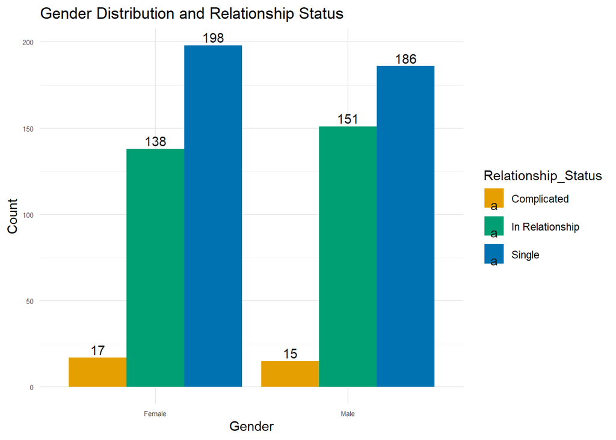

```r
ggplot(data = students, aes(x = Gender, fill = Relationship_Status)) +
  geom_bar(position = position_dodge(width = 0.9)) +
  geom_text(stat = "count",
            aes(label = after_stat(count), group = Relationship_Status),
            position = position_dodge(width = 0.9),
            vjust = -0.3) +
  labs(title = "Gender Distribution and Relationship Status",
       x = "Gender",
       y = "Count") +
  theme_minimal()
```

[output not shown]

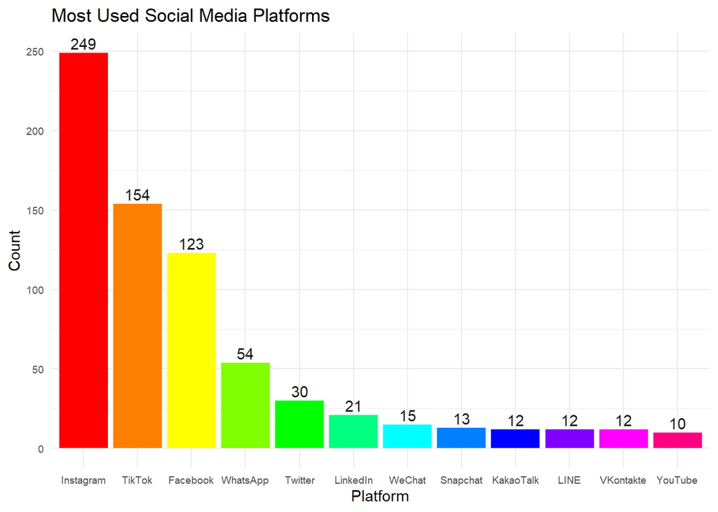

```r
filtered_data <- students %>%
  mutate(Most_Used_Platform = factor(Most_Used_Platform,
                                     levels = names(sort(table(Most_Used_Platform), decreasing = TRUE))))

ggplot(data = filtered_data) +
  geom_bar(mapping = aes(x = Most_Used_Platform, fill = Most_Used_Platform)) +
  scale_fill_manual(values = rainbow(length(unique(filtered_data$Most_Used_Platform)))) +
  geom_text(
    stat = "count",
    aes(x = Most_Used_Platform, label = after_stat(count)),
    position = position_dodge(width = 0.9),
    vjust = -0.3
  ) +
  labs(
    title = "Most Used Social Media Platforms",
    x = "Platform",
    y = "Count"
  ) +
  theme_minimal() +
  theme(
  legend.position = "none",
  axis.text.x = element_text(size = 7),
  axis.text.y = element_text(size = 7),
  theme(axis.text.x = element_text(angle = 45, hjust = 1)))
```

```r
sleep_description$sleep_category <- factor(
  sleep_description$sleep_category,
  levels = c("Poor (<5h)", "Fair (7-9h)", "Good (9h+)")
)
```

[output not shown]

[figure not shown]

```r
ggplot(data = sleep_description) +
  geom_boxplot(
    mapping = aes(x = sleep_category, y = Addicted_Score),
    fill = "#69b3a2",
    color = "black"
  ) +
  labs(
    title = "Social Media Addiction Score by Sleep Quality",
    x = "Sleep Category",
    y = "Addiction Score (0–10)"
  ) +
  theme_minimal() +
  theme(
    plot.title = element_text(face = "bold", hjust = 0.7),
    axis.title = element_text(face = "bold"),
    axis.text.x = element_text(size = 9),
    axis.text.y = element_text(size = 9)
  )
```

[output not shown]

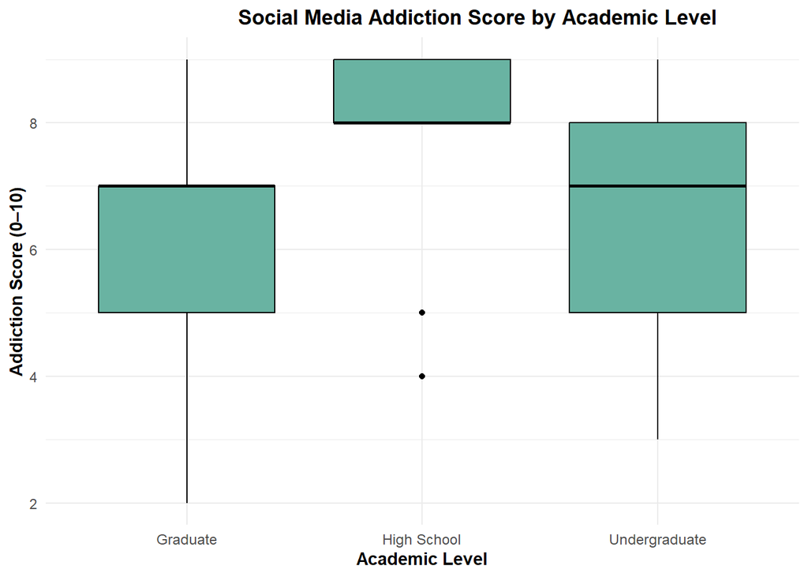

```r
ggplot(data = students) +
  geom_boxplot(
    mapping = aes(x = Academic_Level, y = Addicted_Score),
    fill = "#69b3a2",
    color = "black"
  ) +
  labs(
    title = "Social Media Addiction Score by Academic Level",
    x = "Academic Level",
    y = "Addiction Score (0–10)"
  ) +
  theme_minimal() +
  theme(
    plot.title = element_text(face = "bold", hjust = 0.7),
    axis.title = element_text(face = "bold"),
    axis.text.x = element_text(size = 9),
    axis.text.y = element_text(size = 9)
  )
```

Key Insights from the Graph Analysis:

### Conclusion

To support students’ well-being and academic performance, we recommend setting daily usage limits, using app blockers during study times, maintaining healthy sleep routines by avoiding screens before bedtime, and staying mindful of how excessive use may affect relationships and academic outcomes.